# Integrated analysis and modelling of contaminant mixtures and transcriptomic responses in Tree Swallow (Tachycineta bicolor) nestlings in the Great Lakes

Chi Yen Tseng<sup>1</sup>, Christine M. Custer<sup>2</sup>, Thomas W. Custer<sup>2</sup>, Paul M. Dummer<sup>2</sup>, Natalie Karouna‐Renier<sup>3</sup> and Cole W. Matson<sup>1</sup>

1. Department of Environmental Science, The Institute of Ecological, Earth, and Environmental Sciences (TIE3S), and the Center for Reservoir and Aquatic Systems Research (CRASR), Baylor University, Waco, Texas 76798, United States
2. Upper Midwest Environmental Sciences Center, U.S. Geological Survey, La Crosse, Wisconsin 54603, United States
3. U.S. Geological Survey, Eastern Ecological Science Center (EESC) at Patuxent, Beltsville, Maryland 20705, United States

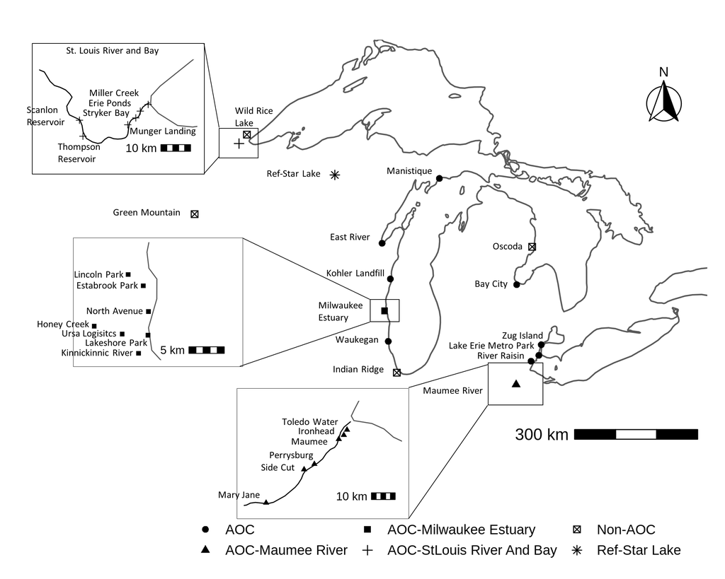

**All the sites included in this study**

Detail location can be downloaded here at GLRI_site_details

## Load all packages

```r
library(glmnet)
library(edgeR)
library(readr)
library(tidyverse)
library(foreach)
library(doParallel)
library(reshape2)
library(stringr)
library(ggpubr)
library(ggrepel)
library(ComplexHeatmap)
library(ggplot2)
library(GGally)
```

## Prepare global gene expression data and contaminant data

**`GLRI_coldata`**

chemistry data (“Dioxin” “MultiRedsiduePest” “PAHs” “PBDEs” “LRPCBs” “HRPCBs” “Pesticides” “PFCs” “PPCPs”)  
- `data.contaminants.majorSubset.geo.bysite`

geometric mean of each contaminant key by site

**`contaminants.coldata.subset`**

only includes the nestlings with genomic information and removes PAHs data

**`ID.convert`**

gene ID convertion table between tree swallow gene pseudo name and chicken gene name

**`siteMAP.all`**

site ID and propersite name convertion Table

**`dds.bothSex.adjusted or counts.tswallow`**

normalized count matrix for all nestlings, adjusted for batch difference

**`Cont.major.list`**

major contaminants (“Nonachlor, cis-_C”, “Heptachlor Epoxide_C”, “Nonachlor, trans-_C”, “PFDA_C”, “Chlordane, oxy-_C”, “Total Parent PAHs”, “Total PBDE”, “Total PAHs”,“Total PCBs”,“Total_PFCs”)

**`counts.tswallow.norm`**

vst transformed normalized counts

## 1. Determine lasso regression models to predict PCB concentrations

### Load top genes list

`topgenelistPCBs.rds`, including 91 genes which were appeared more than 5% in the first round of lasso regression analysis in the cross-validation. Detail script of first round lasso models were provided here

### Load self-determined lasso training and permorance evaluation models

- **`lasso.by.site.PCBs.top100.lasso(i,Con,Con_ind, test.genelist, s, lam.m)`**

  leave one ( `i` site) out to build lasso regression models to predict concentrations of contaminant (`Con` and `Con_ind`) using top predictor genes (`genelist`), model parameter lamda (`s`: 1se and `lam.m`: minimum log10 lamda value to test model fit)
- **`Run_lasso.by.site.PCBs.top100.lasso(re, Con, Con_ind, s, lam.m)`**

  Run `lasso.by.site.PCBs.top100.lasso` function `re` times
- **`evaluation_funciton.bysite`**

  calculate site performance by site, mean square error (MSE), accuracy, and error rate are calculated based on predicted site geometric mean versus actual geometric mean
- **`evaluation_funciton.byindividual`**

  calculate site performance by individual nest, ignoring site factor, mean square error (MSE), accuracy, and error rate are calculated based on predicted vs actual value

```r
## Con, Con_ind: contaminant type; test.genelist: top genes selected from the first run; s: lamda.sequence (l.1se,l.min,l.median); lam.m: lambda = 10^seq(0,lam.m,length=600)
lasso.by.site.PCBs.top100.lasso <- function(i,Con,Con_ind, test.genelist, s, lam.m) {
  ## genomic samples with the same nest id
  nestid <- contaminants.coldata.subset2 %>% filter(Key == Con_ind) %>% dplyr::pull(MergeID)
  match1 <- colnames(counts.tswallow.norm) %in% nestid
  counts.con  <-  counts.tswallow.norm[,match1]
  counts.con.batch <- as.factor(as.character(dds.bothSex.adjusted$batch2)[match1])
  counts.con.sex <- as.factor(as.character(dds.bothSex.adjusted$sex)[match1])
  contamin.raw <- contaminants.coldata.subset2 %>% filter(Key == Con_ind) %>% dplyr::pull(value.adjust) %>% log10()
  contamin.matrix <- contaminants.coldata.subset2 %>% dplyr::slice(match(colnames(counts.con), contaminants.coldata.subset2$MergeID)) %>% filter(Key == Con_ind)
  counts.con.contamin <- log10(contamin.matrix$value.adjust) ## get log10 value to suppress potential outlier
  site.list = unique(as.character(dds.bothSex.adjusted$site[match1]))
  ## Building matrix
  if (length(levels(counts.con.batch)) > 1) {
    counts.con.t <- as.data.frame(t(counts.con[test.genelist,]))
    counts.con.t <- cbind(counts.con.t, batch = counts.con.batch, sex = counts.con.sex, contaminant = counts.con.contamin)
    m <- model.matrix(contaminant ~ batch +., counts.con.t) # m for training
    m <- m[,-1] } else {
      counts.con.t <- as.data.frame(t(counts.con[test.genelist,]))
      counts.con.t <- cbind(counts.con.t, sex = counts.con.sex, contaminant = counts.con.contamin)
      m <- model.matrix(contaminant ~ ., counts.con.t)
      m <- m[,-1] }
  ## to include all genomic samples as m2
  nestid <- contaminants.coldata.subset2 %>% filter(Key == Con_ind) %>% dplyr::pull(MergeID)
  counts.con2  <-  counts.tswallow.norm
  counts.con.batch2 <- as.factor(as.character(dds.bothSex.adjusted$batch2))
  counts.con.sex2 <- as.factor(as.character(dds.bothSex.adjusted$sex))

  ## Building matrix
  if (length(levels(counts.con.batch2)) > 1) {
    counts.con.t2 <- as.data.frame(t(counts.con2[test.genelist,]))
    counts.con.t2 <- cbind(counts.con.t2, batch = counts.con.batch2, sex = counts.con.sex2)
    m2 <- model.matrix(~ batch +., counts.con.t2) # m2 for validation in leave one site out
    m2 <- m2[,-1] } else {
      counts.con.t2 <- as.data.frame(t(counts.con2[test.genelist,]))
      counts.con.t2 <- cbind(counts.con.t2, sex = counts.con.sex2)
      m2 <- model.matrix( ~ ., counts.con.t2)
      m2 <- m2[,-1] }

  site.count.nest.subset = table(str_sub(colnames(counts.con),3,4))
  site.count.genomic.subset = table(str_sub(colnames(counts.con2),3,4))
  # sites_verifications = c("ER", "HW", "LS", "PB", "SC", "SP", "ST", "TH", "WK")

  ## CV leave one out by site
    test.site = str_sub(row.names(m),3,4) %in% site.list[i]
    l.1se <- {} ; l.min <- {}

    for (j in 1:20) {
      cvfit <- cv.glmnet(x=m[!test.site,], y=counts.con.t$contaminant[!test.site], nfold = 10, alpha = 1, lambda = 10^seq(0,lam.m,length=600), relax =FALSE)

      l.1se <- c(l.1se, cvfit$lambda.1se)
      l.min <- c(l.min, cvfit$lambda.min)

    } # repeat 20 times and pick median lamda to avoid picking extreme in 10 folds cross validation
    l.1se <- median(l.1se)
    l.min <- median(l.min)
    l.median <- exp(mean(c(log(l.min),log(l.1se))))
    lamda.sequence <- c(l.1se,l.min,l.median)

    ByNestResult.withlamdaP <- {}
    training.site = sample(which(!test.site), round(sum(!test.site)*0.9))
    fit.lasso <- glmnet(x=m[training.site,], y=counts.con.t$contaminant[training.site], alpha = 1, lambda = 10^seq(0,lam.m,length=600)) # lasso model using training set

    ## get all the metrics c(features, dev.ratio, lamda)
    variables = coef(fit.lasso, s = lamda.sequence[s])[,1]
    variables = variables[variables != 0][-1]
    dev.ratio = fit.lasso$dev.ratio[which(sort(c(lamda.sequence[s],10^seq(0,lam.m,length=600)),decreasing = TRUE) == lamda.sequence[s])[1] -1]

    ## get all predictions using all avaialble genomic samples
    test.site2 = str_sub(row.names(m2),3,4) == site.list[i]

    ## lasso
    predict.all.genomic.samples.subset <- predict(fit.lasso, newx = m[test.site,], s = lamda.sequence[s]) ## only use overlapped portion
    predict.all.genomic.samples <- predict(fit.lasso, newx = m2[test.site2,], s = lamda.sequence[s]) ## only use overlapped portion

    predict.all.genomic.samples.subset.lasso = predict.all.genomic.samples.subset[,1]
    predict.all.genomic.samples.lasso = predict.all.genomic.samples[,1]

    predict.all.genomic.samples.subset.lasso.mean = mean(predict.all.genomic.samples.subset.lasso)
    names(predict.all.genomic.samples.subset.lasso.mean) = site.list[i]
    predict.all.genomic.samples.lasso.mean = mean(predict.all.genomic.samples.lasso)
    names(predict.all.genomic.samples.lasso.mean) = site.list[i]

    ## combine
    result = list(variables =variables, dev.ratio = dev.ratio ,lamda.sequence = lamda.sequence, predict.all.genomic.samples.subset.lasso = predict.all.genomic.samples.subset.lasso, predict.all.genomic.samples.subset.lasso.mean = predict.all.genomic.samples.subset.lasso.mean, predict.all.genomic.samples.lasso = predict.all.genomic.samples.lasso, predict.all.genomic.samples.lasso.mean = predict.all.genomic.samples.lasso.mean)
  return(result)
}
Run_lasso.by.site.PCBs.top100.lasso <- function(re, Con, Con_ind, s, lam.m) {
  lassoCVbysite <- foreach(i = rep(1:31, each = re), .packages = c("dplyr","glmnet","stringr"), .combine = 'cbind', .export = c("lasso.by.site.PCBs.top100.lasso", "contaminants.coldata.subset2","counts.tswallow.norm","dds.bothSex.adjusted", "test.genelist", "data.contaminants.majorSubset.geo.bysite")) %dopar% {
    LassoCVbysite_result <- Vectorize(lasso.by.site.PCBs.top100.lasso(i,Con,Con_ind, test.genelist, s, lam.m))
    return(LassoCVbysite_result)
  }

  return(lassoCVbysite)
}
evaluation_funciton.bysite <- function(Result) {
  result.all <- {}
  evaluation.result <- {}
  predictions = Result
  ## geoMean: only use overlapped genomic site individulas training samples to calculate geoMean
  predictions2 = data.frame(site = names(Result), predictions, geoMean = contaminant.geoMean.bysite.genomic[names(Result)], b33 =  quantile(contaminant.geoMean.bysite, probs = 0.33, na.rm = FALSE, names = FALSE), t33 = quantile(contaminant.geoMean.bysite, probs = 0.67, na.rm = FALSE, names = FALSE))
  predictions3 = cbind(predictions2, is.top33 = predictions2$geoMean >= predictions2$t33, is.bottom33 = predictions2$geoMean <= predictions2$b33, is.top.predict = predictions2$predictions >= predictions2$t33, is.bottom.predict = predictions2$predictions <= predictions2$b33)
  predictions.all = predictions3
  predictions.all$delta = (predictions.all$predictions - predictions.all$geoMean)^2
  MSE = sum(predictions.all$delta)/nrow(predictions.all)

  error.top =  sum(predictions.all$is.top.predict & predictions.all$is.bottom33)/ sum(predictions.all$is.top.predict)

  error.bottom = sum(predictions.all$is.bottom.predict & predictions.all$is.top33)/ sum(predictions.all$is.bottom.predict)

  error.both = sum((predictions.all$is.top.predict & predictions.all$is.bottom33)  | (predictions.all$is.bottom.predict & predictions.all$is.top33))/ sum(predictions.all$is.bottom.predict | predictions.all$is.top.predict)

  accuracy.top =  sum(predictions.all$is.top.predict & predictions.all$is.top33)/ sum(predictions.all$is.top.predict)

  accuracy.bottom = sum(predictions.all$is.bottom.predict & predictions.all$is.bottom33)/ sum(predictions.all$is.bottom.predict)

  accuracy.both = sum((predictions.all$is.top.predict & predictions.all$is.top33)  | (predictions.all$is.bottom.predict & predictions.all$is.bottom33))/ sum(predictions.all$is.bottom.predict | predictions.all$is.top.predict)

  testing_ratio = c(top_ratio = sum(predictions.all$is.top33)/nrow(predictions.all), bottom_ratio = sum(predictions.all$is.bottom33)/nrow(predictions.all))

  performance.result = c(error.top = error.top,error.bottom = error.bottom, error.both = error.both, accuracy.top = accuracy.top ,accuracy.bottom = accuracy.bottom,accuracy.both = accuracy.both, testing_ratio, MSE = MSE)
  evaluation.result = list(predictions.by.site=predictions.all, performance.result = performance.result)
  return(evaluation.result)
}
evaluation_funciton.byindividual <- function(Result) {
  result.all <- {}
  evaluation.result <- {}
  predictions = Result
  ## geoMean: only use overlapped genomic site individulas training samples to calculate geoMean
  predictions2 = data.frame(mergeID = names(Result), predictions, actural = contamin.array[names(predictions)] , b33 =  quantile(contaminant.geoMean.bysite, probs = 0.33, na.rm = FALSE, names = FALSE), t33 = quantile(contaminant.geoMean.bysite, probs = 0.67, na.rm = FALSE, names = FALSE))
  predictions3 = cbind(predictions2, is.top33 = predictions2$actural >= predictions2$t33, is.bottom33 = predictions2$actural <= predictions2$b33, is.top.predict = predictions2$predictions >= predictions2$t33, is.bottom.predict = predictions2$predictions <= predictions2$b33)
  predictions3 = predictions3[!is.na(predictions3$is.bottom33),]
  predictions.all = predictions3
  predictions.all$delta = (predictions.all$predictions - predictions.all$actural)^2
  MSE = sum(predictions.all$delta)/nrow(predictions.all)


  error.top =  sum(predictions.all$is.top.predict & predictions.all$is.bottom33)/ sum(predictions.all$is.top.predict)

  error.bottom = sum(predictions.all$is.bottom.predict & predictions.all$is.top33)/ sum(predictions.all$is.bottom.predict)

  error.both = sum(predictions.all$is.top.predict & predictions.all$is.bottom33 | predictions.all$is.bottom.predict & predictions.all$is.top33)/ sum(predictions.all$is.top.predict | predictions.all$is.bottom.predict)

  accuracy.top =  sum(predictions.all$is.top.predict & predictions.all$is.top33)/ sum(predictions.all$is.top.predict)

  accuracy.bottom = sum(predictions.all$is.bottom.predict & predictions.all$is.bottom33)/ sum(predictions.all$is.bottom.predict)

  accuracy.both = sum((predictions.all$is.top.predict & predictions.all$is.top33)  | (predictions.all$is.bottom.predict & predictions.all$is.bottom33))/ sum(predictions.all$is.bottom.predict | predictions.all$is.top.predict)

  testing_ratio = c(top_ratio = sum(predictions.all$is.top33)/nrow(predictions.all), bottom_ratio = sum(predictions.all$is.bottom33)/nrow(predictions.all))

  performance.result = c(error.top = error.top,error.bottom = error.bottom, error.both = error.both, accuracy.top = accuracy.top ,accuracy.bottom = accuracy.bottom,accuracy.both = accuracy.both, testing_ratio, MSE = MSE)
  evaluation.result = list(predictions.all,performance.result)
  return(evaluation.result)
}
```

### Run Lasso regression analysis between top Gene (91 genes) and PCB concentrations

Run lasso analysis with leave one site out cross validatino with 40 rounds, 40 * 31 sites = 1240 cross-validation and resample 90% of training individuals every trial.

```r
### Total PCBs
Con="PCBs_data";Con_ind="TOTAL PCBs"
## refresh between chemicals
lamda.sequence <- {}
Result.lasso.assessment <- {}
variables <- {}
predict.site.test <- {}
## result measures
rlassoResult <- list()

# prepare data
contaminants.coldata.subset2 <-contaminants.coldata.subset
### Individual chemicals
contaminants.coldata.subset2 <- contaminants.coldata.subset2 %>% filter(Key == Con_ind)
contaminants.coldata.subset2 <- contaminants.coldata.subset2 %>% filter(!is.na(value.adjust)) ## remove those with value == "NR"
## combine all duplicated items using mean value becasue they have the same nest id
contaminants.coldata.subset2 <- contaminants.coldata.subset2 %>% group_by(MergeID,Species,Matrix,AOC,Proper_Site,Key,type,class,MergeSite,proper_site2) %>% summarise(value.adjust2 = mean(value.adjust)) %>% ungroup()
colnames(contaminants.coldata.subset2)[colnames(contaminants.coldata.subset2) == "value.adjust2"] <- "value.adjust" ## change the name back
# print(sum(duplicated(contaminants.coldata.subset2$MergeID))) ## check duplication again
## read topgenelist 91 genes
test.genelist = readRDS("topgenelistPCBs.rds")$total.PCBs

contaminant.geoMean.bysite <- data.contaminants.majorSubset.geo.bysite %>% filter(Key == Con_ind) %>% dplyr::pull(value.geoMean) %>% log10() ## log10 of contaminant value
names(contaminant.geoMean.bysite) <- data.contaminants.majorSubset.geo.bysite %>% filter(Key == Con_ind) %>% dplyr::pull(MergeSite)
nestid <- contaminants.coldata.subset2 %>% filter(Key == Con_ind) %>% dplyr::pull(MergeID)
match1 <- colnames(counts.tswallow.norm) %in% nestid
counts.con  <-  counts.tswallow.norm[,match1]
contamin.matrix <- contaminants.coldata.subset2 %>% dplyr::slice(match(colnames(counts.con), contaminants.coldata.subset2$MergeID)) %>% filter(Key == Con_ind) %>%　mutate(value.adjust.log = log10(value.adjust))
contamin.array <- contamin.matrix$value.adjust.log
names(contamin.array) = contamin.matrix$MergeID
contamin.matrix.mean <- contamin.matrix %>% group_by(MergeSite) %>% summarise(geoMean = mean(value.adjust.log)) %>% ungroup()
contamin.matrix.mean$MergeSite[31] = "NA"
contaminant.geoMean.bysite.genomic <- contamin.matrix.mean$geoMean
names(contaminant.geoMean.bysite.genomic) <- contamin.matrix.mean$MergeSite
```

```r
# Run lasso analysis with leave one site out cross validatino with 40 rounds, 40 * 31 sites = 1240 cross-validation and resample 90% of training individuals every trial.
print(c("2nd lasso cv",Con_ind))
t1 =  Sys.time()
cl <- parallel::makeCluster(12)
doParallel::registerDoParallel(cl)
t1 = Sys.time()
PCBs_CV_bySite_result = Run_lasso.by.site.PCBs.top100.lasso(re = 40, Con = Con, Con_ind = Con_ind, s = 1,lam.m = -2)
t2 =  Sys.time()
t2 -t1
parallel::stopCluster(cl)

# Result list : 1. variables, 2.  dev.ratio 3. lamda.sequence 4. predict.all.genomic.samples.subset.lasso 5. predict.all.genomic.samples.subset.lasso.mean 6. predict.all.genomic.samples.lasso
# 7. predict.all.genomic.samples.lasso.mean
# saveRDS(PCBs_CV_bySite_result, "PCBs_CV_bySite_result2nd.rds")
```

### Lasso regression analysis results for predicting PCB concentrations

```r
PCBs_CV_bySite_result <- readRDS("PCBs_CV_bySite_result2nd.rds")
# PCBs_CV_bySite_result by site
Result = unlist(unname(PCBs_CV_bySite_result[5,])) ##  genomic samples overlapped with contaminated samples
PCBs.performance.bysite.overlapped.report = evaluation_funciton.bysite(Result = Result)

Result = unlist(unname(PCBs_CV_bySite_result[7,])) ## all genomic samples
PCBs.performance.bysite.allgenomic.report = evaluation_funciton.bysite(Result = Result)
#
# ## overlapped portion PCBs
# $performance.result
#  error.top    error.bottom      error.both    accuracy.top accuracy.bottom   accuracy.both       top_ratio    bottom_ratio             MSE
#     0.132075472     0.006072874     0.050065876     0.569811321     0.844129555     0.748353096     0.322580645     0.451612903     0.230140947

# # ## all genomic samples PCBs
# $performance.result
# error.top    error.bottom      error.both    accuracy.top accuracy.bottom   accuracy.both       top_ratio    bottom_ratio             MSE
#     0.090551181     0.006507592     0.036363636     0.614173228     0.854663774     0.769230769     0.322580645     0.451612903     0.233187702

# PCBs_CV_bySite_result by individual, only use overlapped portion
Result = unlist(unname(PCBs_CV_bySite_result[4,])) ##  genomic samples overlapped with contaminated samples
PCBs.performance.byindividual.overlapped.report = evaluation_funciton.byindividual(Result = Result)

# error.top    error.bottom      error.both    accuracy.top accuracy.bottom   accuracy.both       top_ratio    bottom_ratio             MSE
#       0.1002028       0.1817585       0.1452929       0.7346856       0.6286089       0.6760385       0.4234694       0.3724490       0.3985988

## other performance metrics
# determine predictor genes; variablers
variables.length.summary <-  summary(sapply(1:length(PCBs_CV_bySite_result[1,]), function(x) length(PCBs_CV_bySite_result[1,][[x]])))
variables.length.p95 <- quantile(sapply(1:length(PCBs_CV_bySite_result[1,]), function(x) length(PCBs_CV_bySite_result[1,][[x]])),0.95)
variables <- names(sort(table(names(unlist(unname(PCBs_CV_bySite_result[1,])))),decreasing = TRUE)[1:variables.length.p95])
variables <- list(id = variables, name = na.omit(ID.convert$GeneName[match(variables,ID.convert$GeneID2)]))
variables.coef = unlist(lapply(1:ncol(PCBs_CV_bySite_result), function(x) na.omit(PCBs_CV_bySite_result[1,][[x]][variables$id])))
geomean_func = function(x) {exp(mean(log(x)))}
variables.coef.aggregate = aggregate(variables.coef, list(Gene = names(variables.coef)),mean)
colnames(variables.coef.aggregate)[2] = "coef"
variables.coef.aggregate = data.frame(name = ID.convert$GeneName[match(variables.coef.aggregate$Gene, ID.convert$GeneID2)], variables.coef.aggregate)

# R square, or deviance ratio

# dev.ratio
dev.ratio.n <- ncol(PCBs_CV_bySite_result)
dev.ratio.mean <- mean(unlist(unname(PCBs_CV_bySite_result[2,])))
dev.ratio.s <- sd(unlist(unname(PCBs_CV_bySite_result[2,])))
margin <- qt(0.975,df=dev.ratio.n-1)*dev.ratio.s/sqrt(dev.ratio.n)
dev.ratio.PCBs = c(mean = dev.ratio.mean, margin = margin)
# print(dev.ratio.PCBs)
# mean      margin
# 0.766489759 0.001045139


# ##
predict.result = unlist(unname(PCBs_CV_bySite_result[4,])) # only the overlapping part
predict.result2 = unlist(unname(PCBs_CV_bySite_result[5,])) # only the overlapping part site average
Predictions.by.site = tibble(site= names(predict.result2), predictions= predict.result2,  genomic.PCB.mean = contaminant.geoMean.bysite.genomic[names(predict.result2)], proper_site2 = siteMAP.all$propersite[match(names(predict.result2), siteMAP.all$SiteID)])
Predictions.by.individual = tibble(MergeID = names(predict.result), proper_site2 = siteMAP.all$propersite[match(str_sub(names(predict.result),3,4), siteMAP.all$SiteID)], predicted.PCBs = predict.result,  measured.PCBs = contamin.array[names(predict.result)])
PCBs.predictions.lasso.aggregate = list(by.site = Predictions.by.site, by.individual = Predictions.by.individual)
# saveRDS(PCBs.predictions.lasso.aggregate, "PCBs.predictions.lasso.aggregate.rds")

# list all predictions, variables, R2 and model performance
PCBs.performance.report <- list(PCBs.performance.bysite.overlapped.report = PCBs.performance.bysite.overlapped.report, PCBs.performance.bysite.allgenomic.report = PCBs.performance.bysite.allgenomic.report, PCBs.performance.byindividual.overlapped.report = PCBs.performance.byindividual.overlapped.report, PCB.variables = list(variables,variables.coef.aggregate), PCBs.dev.ratio = dev.ratio.PCBs)
# saveRDS(PCBs.performance.report, "PCBs.performance.report.rds")
```

Because not evey nest was selected for measuring chemistry, the following performance metrics are calculated by

- PCBs_CV_bySite_result by site: only include those nest with chemistry measurements and calculate accuracy and errors using predicted site geometric mean
- PCBs.performance.bysite.allgenomic: include all nest with or without chemistry measurements and calculate accuracy and errors using predicted site geometric mean
- PCBs.performance.byindividual: include all nest with chemistry measurements and calculate accuracy and errors using predicted individual concentrations.

```r
Result = unlist(unname(PCBs_CV_bySite_result[5,])) ##  genomic samples overlapped with contaminated samples
PCBs.performance.bysite.overlapped.report = evaluation_funciton.bysite(Result = Result)

Result = unlist(unname(PCBs_CV_bySite_result[7,])) ## all genomic samples
PCBs.performance.bysite.allgenomic.report = evaluation_funciton.bysite(Result = Result)
#
# ## overlapped portion PCBs
# $performance.result
# error.top    error.bottom    accuracy.top accuracy.bottom   accuracy.both       top_ratio    bottom_ratio             MSE
# 0.111969112     0.004056795     0.583011583     0.845841785     0.755319149     0.322580645     0.451612903     0.229426453
# ## all genomic samples PCBs
# $performance.result
# error.top    error.bottom    accuracy.top accuracy.bottom   accuracy.both       top_ratio    bottom_ratio             MSE
# 0.065306122     0.004347826     0.632653061     0.847826087     0.773049645     0.322580645     0.451612903     0.232414433

# PCBs_CV_bySite_result by individual, only use overlapped portion
Result = unlist(unname(PCBs_CV_bySite_result[4,])) ##  genomic samples overlapped with contaminated samples
PCBs.performance.byindividual.overlapped.report = evaluation_funciton.byindividual(Result = Result)

# error.top    error.bottom    accuracy.top accuracy.bottom   accuracy.both       top_ratio    bottom_ratio             MSE
# 0.1002028       0.1817585       0.7346856       0.6286089       0.6760385       0.4234694       0.3724490       0.3985988

performance.metrics <- round(data.frame(PCBs.performance.bysite.overlapped.report$performance.result, PCBs.performance.bysite.allgenomic.report$performance.result, PCBs.performance.byindividual.overlapped.report[[2]]),3)
colnames(performance.metrics) <- c("by.site (with chemistry only)", "by.site (all genomic samples)", "by.nest (with chemistry only)")
# saveRDS(performance.metrics, "PCB.performance.metrics.rds")
```

### PCBs lasso prediction results

- **Predicted vs actural yy plot by site**

  predicted vs actural PCB concentration; color by those site with prediction value above or below top 1/3 or bottom 1/3 PCB among all the sites
- **Predicted vs actural yy plot by site with 99.9% confidence interval**

  add 99.9% CI on Predicted vs actural yy plot by site
- **Remediation effectiveness evaluation in Waukegan**

  add Waukegan value throughout the year on Predicted vs actural yy plot by site
- **Predicted vs actural yy plot by nest**

  the model is trained by individual nest
- **model performance**

  accuracy and error ; accurate predicting top 1/3 or bottom 1/3 ; error : predicting top 1/3 but end up bottom 1/3 or vice versa
- **Predictor genes selected in the model**

  list the predictor genes in the model

#### Predicted vs actural yy plot by site

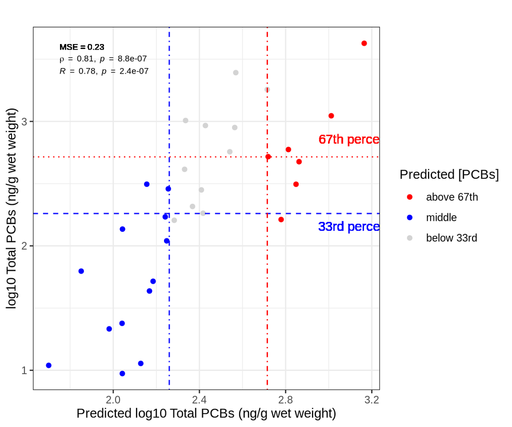

Predicted vs actural PCB concentrations yy plot by site

#### Predicted vs actural yy plot by site with 99.9% confidence interval

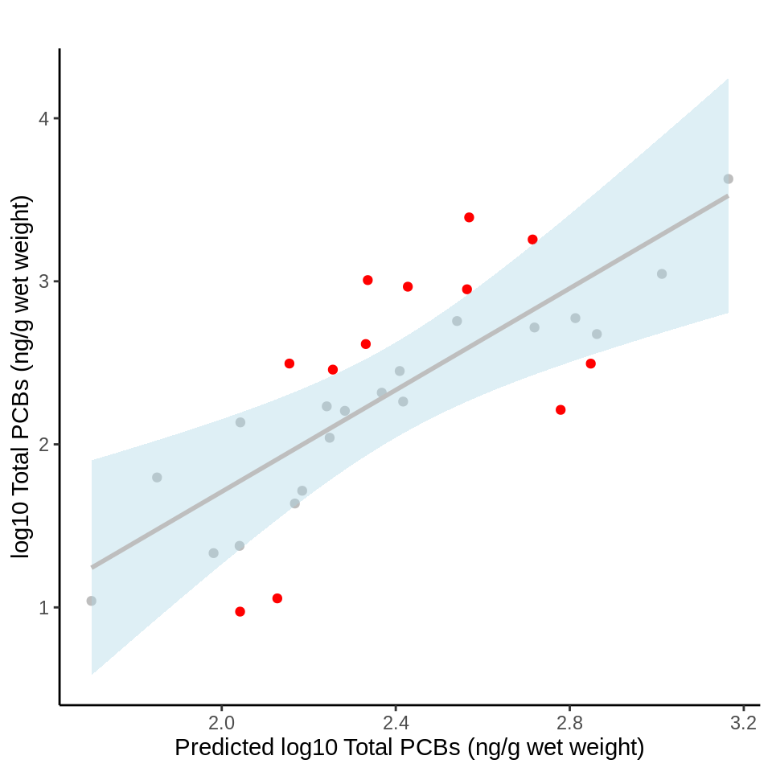

#### Remediation effectiveness evaluation in Waukegan

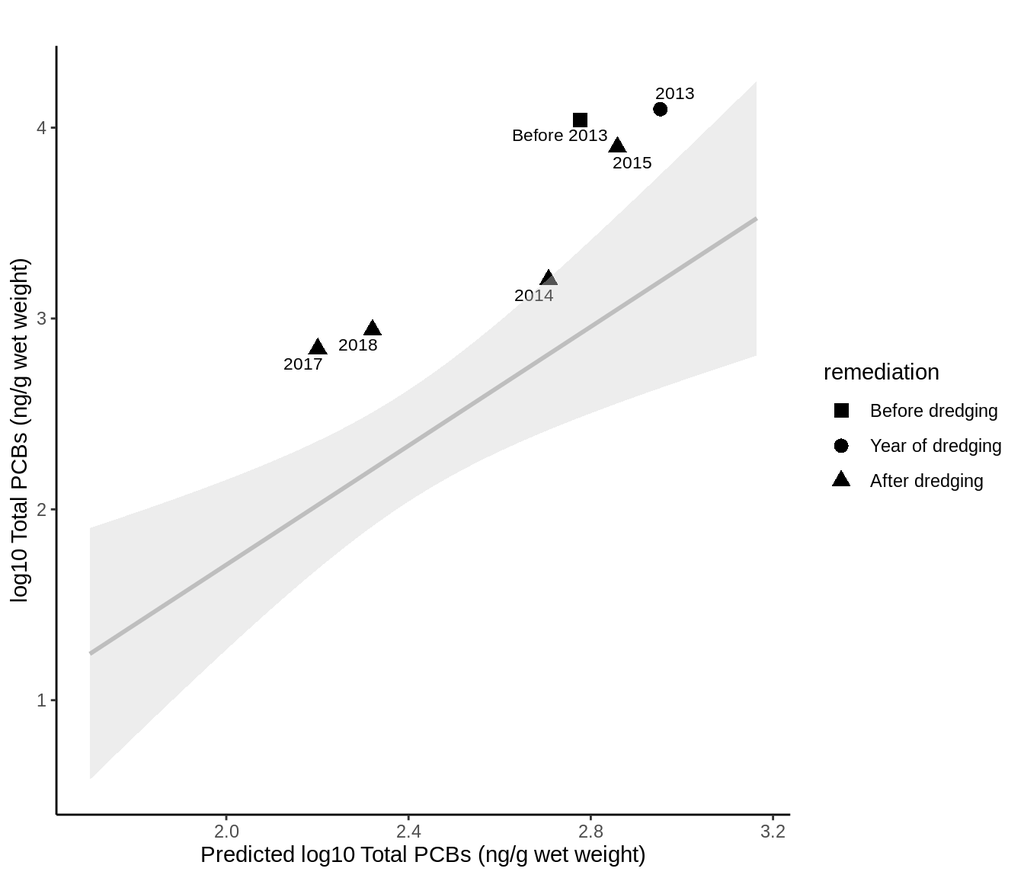

#### Predicted vs actural yy plot by nest

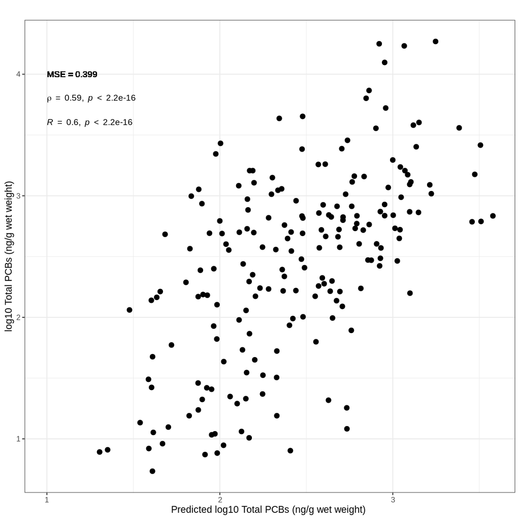

#### model performance

PCBs lasso regression model performance metrics

|  | by.site (with chemistry only) | by.site (all genomic samples) | by.nest (with chemistry only) |
| --- | --- | --- | --- |
| error.top | 0.132 | 0.091 | 0.100 |
| error.bottom | 0.006 | 0.007 | 0.182 |
| error.both | 0.050 | 0.036 | 0.145 |
| accuracy.top | 0.570 | 0.614 | 0.735 |
| accuracy.bottom | 0.844 | 0.855 | 0.629 |
| accuracy.both | 0.748 | 0.769 | 0.676 |
| top_ratio | 0.323 | 0.323 | 0.423 |
| bottom_ratio | 0.452 | 0.452 | 0.372 |
| MSE | 0.230 | 0.233 | 0.399 |

#### Predictor genes selected in the model

PCBs top predictor genes and coefficient

| name | coef | Gene |
| --- | --- | --- |
| OPRM1 | 0.0626781 | TacBic00000248 |
| HHIPL2 | 0.0629860 | TacBic00000723 |
| BROX | -0.0765754 | TacBic00000728 |
| ALK | -0.0343974 | TacBic00000778 |
| ahrr | 0.2032059 | TacBic00001060 |
| DNAH5 | -0.0421367 | TacBic00001152 |
| MT-CO2 | 0.0306515 | TacBic00001169 |
| EDN1 | 0.2580644 | TacBic00001272 |
| MRC1 | -0.0445834 | TacBic00001408 |
| NA | -0.0345405 | TacBic00001866 |
| PDE1A | -0.0335550 | TacBic00002231 |
| TDH | -0.0368326 | TacBic00002440 |
| WDR35 | -0.0689035 | TacBic00002543 |
| CPSF3 | -0.1160736 | TacBic00002590 |
| LMBRD1 | -0.0738019 | TacBic00002694 |
| LD | -0.0339494 | TacBic00004095 |
| PLEKHH1 | -0.1973106 | TacBic00004124 |
| NA | 0.0719234 | TacBic00004433 |
| NA | -0.0637095 | TacBic00005036 |
| NA | -0.0547057 | TacBic00005289 |
| MAPK6 | -0.0716260 | TacBic00006048 |
| CCDC78 | 0.0286038 | TacBic00006808 |
| DAGLB | -0.0965885 | TacBic00006993 |
| HYDIN | 0.0160680 | TacBic00007206 |
| FLT4 | -0.0471608 | TacBic00007722 |
| DBN1 | -0.1532679 | TacBic00007823 |
| NA | -0.1268583 | TacBic00007892 |
| SLC17A9 | 0.0313378 | TacBic00008664 |
| ZC2HC1A | -0.0751931 | TacBic00009014 |
| LOC423119 | -0.1004947 | TacBic00009296 |
| MN1 | -0.1422477 | TacBic00009683 |
| NOS1 | -0.1495260 | TacBic00009882 |
| NA | -0.0715350 | TacBic00010159 |
| SLCO1A2 | -0.0209454 | TacBic00010681 |
| PIK3C3 | 0.0274661 | TacBic00011042 |
| ZNF185L | -0.0567324 | TacBic00011230 |
| ARHGAP36 | 0.1152496 | TacBic00011246 |
| SPIA9 | 0.0417792 | TacBic00011339 |
| ETNPPL | -0.0423135 | TacBic00011604 |
| ARHGAP6 | 0.0735161 | TacBic00011724 |
| RPL3 | 0.0500954 | TacBic00012455 |
| NA | 0.0131619 | TacBic00012685 |
| CLDN18 | 0.0408827 | TacBic00012986 |
| NA | -0.1276152 | TacBic00013588 |
| P2RY10 | 0.0980806 | TacBic00013697 |
| HMGCR | 0.0355349 | TacBic00013782 |
| ERRFI1 | -0.0187293 | TacBic00014439 |
| ABCA9 | 0.0371875 | TacBic00014601 |
| NA | -0.0291986 | TacBic00015118 |
| CMTM4 | 0.0638626 | TacBic00015406 |
| CHSY3 | -0.0525856 | TacBic00015571 |
| KCNIP1 | 0.1172414 | TacBic00015722 |
| NA | 0.0512586 | TacBic00016990 |
| NA | 0.0300411 | TacBic00017215 |
| CYP1A5 | 0.0917243 | TacBic00018777 |
| CD248 | 0.2015480 | TacBic00019767 |
| CYP1A4 | 0.0381010 | TacBic00019894 |
| ERAL1 | -0.1732755 | TacBic00020260 |
| LOC776507 | 0.0547346 | TacBic00021387 |
| NA | -0.3323687 | TacBic00021964 |
| NA | 0.0631366 | TacBic00022010 |
| SNX27 | -0.1014123 | TacBic00022200 |

#### MSE by sample size

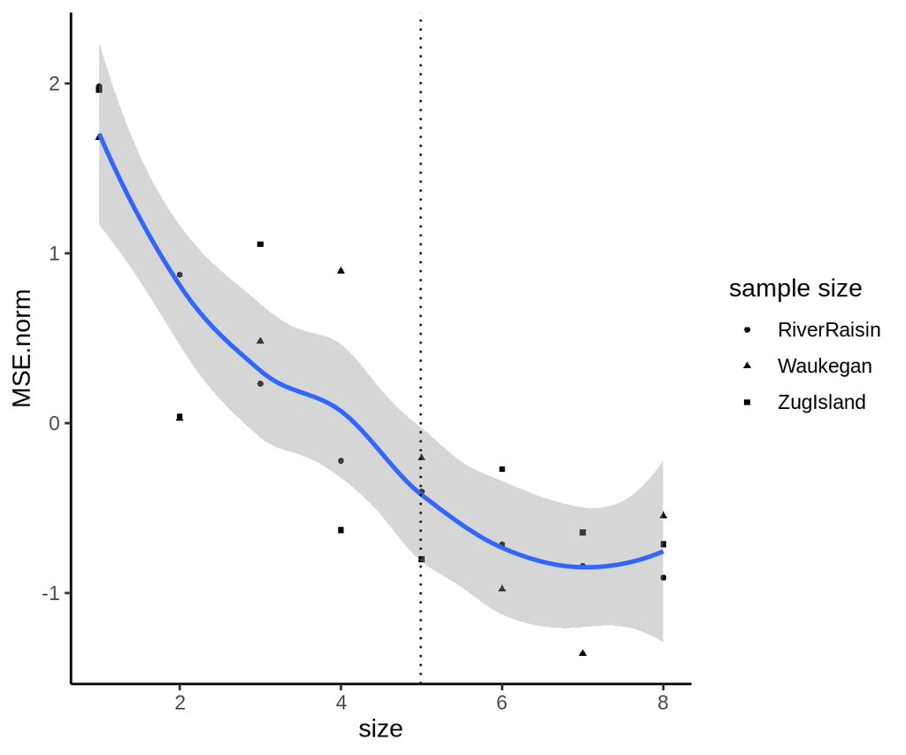

### PCBs top gene predictors functions and pathways

**PCBs top predictor genes heatmap**

correlation between PCB concentration, top predictor gene logFC, top predictor gene model coef. , top predictor gene up or downregulated and their corresponding Reactome pathways

**PCBs lasso selected genes heatmap deatil functions and pathways**

detail GO terms and Reactome pathways

**PCB correlation between logFC logCPM and model coef**

the correlation between top predictor genes between logFC, logCPM (counts), and PCB model coef. measured in top 1/3 logFC individuals

#### PCBs top predictor genes heatmap

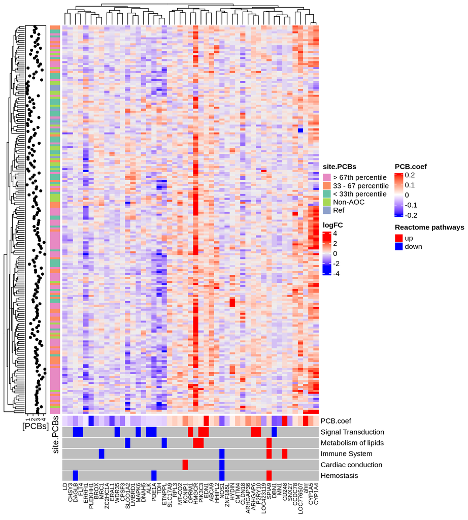

#### PCBs lasso selected genes heatmap deatil functions and pathways

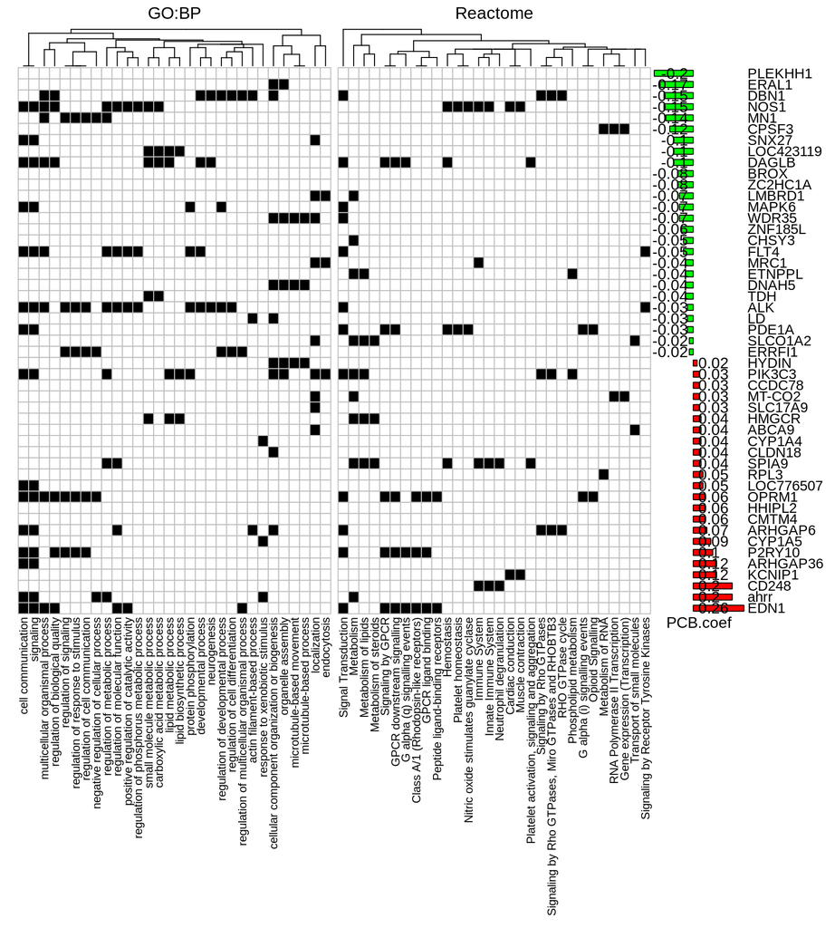

#### PCB correlation between logFC logCPM and model coef

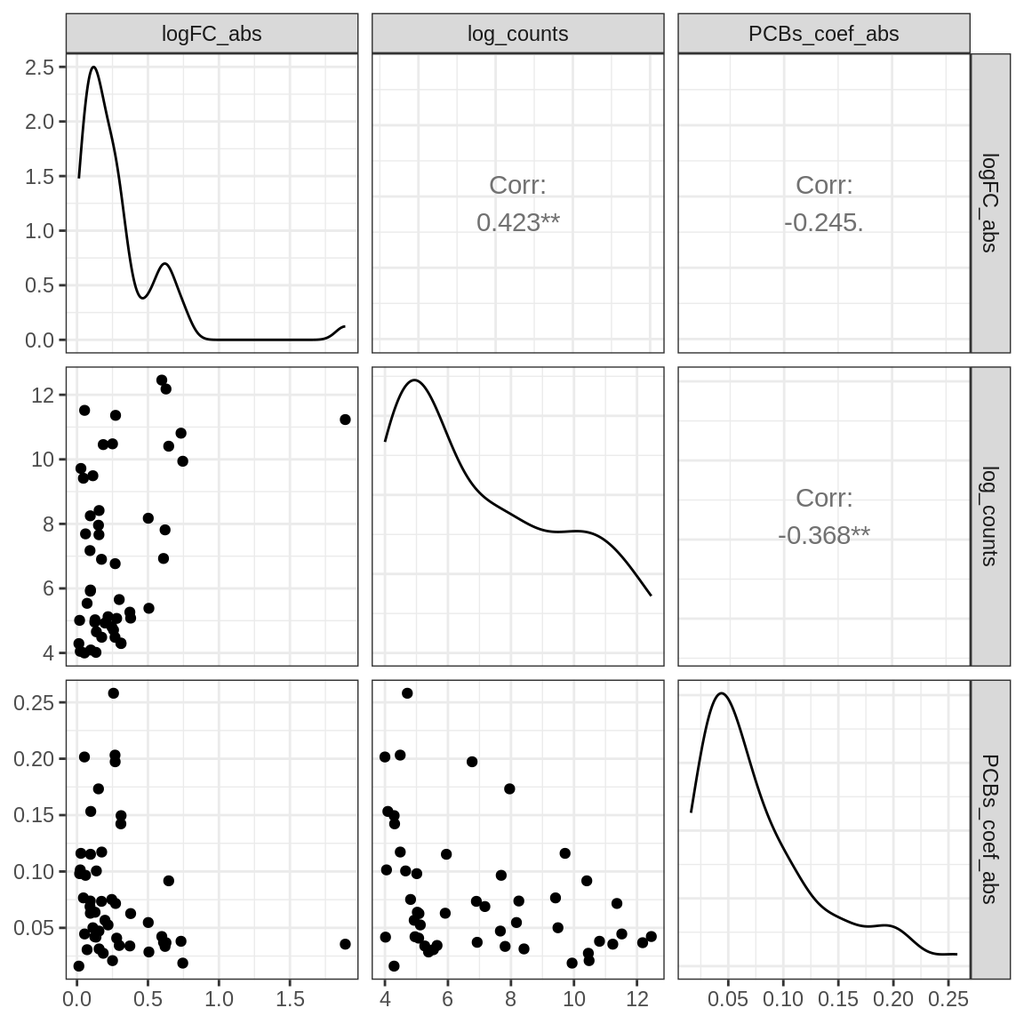

## 2. Determine lasso regression models to predict PAH concentrations

*Start from first round top genes (110) genes and refine lasso regression analysis for the second round*

### Load data

**`GLRI_coldata`**

chemistry data (“Dioxin” “MultiRedsiduePest” “PAHs” “PBDEs” “LRPCBs” “HRPCBs” “Pesticides” “PFCs” “PPCPs”)

**`data.contaminants.majorSubset.geo.bysite`**

geometric mean of each contaminant key by site

**`contaminants.coldata.subset`**

only includes the nestlings with genomic information and removes PAHs data

**`ID.convert`**

gene ID convertion table between tree swallow gene pseudo name and chicken gene name

**`siteMAP.all`**

site ID and propersite name convertion Table

**`dds.bothSex.adjusted or counts.tswallow`**

normalized count matrix for all nestlings, adjusted for batch difference

**`Cont.major.list`**

major contaminants (“Nonachlor, cis-_C”, “Heptachlor Epoxide_C”, “Nonachlor, trans-_C”, “PFDA_C”, “Chlordane, oxy-_C”, “Total Parent PAHs”, “Total PBDE”, “Total PAHs”,“Total PCBs”,“Total_PFCs”)

**`counts.tswallow.norm`**

vst transformed normalized counts

**`topgene.list`**

110 top genes determined from the first round of lasso regression analysis. Detail can be found here

### Load self-determined functions

- `lasso.by.site.top100(Con,Con_ind,i,Min_L,s)` : Lasso leave one (site) out cross-validaiton model training, Min_L for the lowest the lamda cv goes 10^(-2,-3,-4); s: lamda.sequence: 1) 1se 2) min 3) log median
- `Run_lasso_by_site.top100(n,Con,Con_ind,N_train,Min_L,s)` : Run `lasso.by.site.top100` with n runs throughout all 28 sites = 28n
- `evaluation_funciton.bysite.PAH` : generate performance metrics

```r
# N: N repeat leave one (site) out validation;  Min_L for the lowest the lamda cv goes 10^(-2,-3,-4); s: lamda.sequence: 1) 1se 2) min 3) log median
lasso.by.site.top100 <- function(Con,Con_ind,i,Min_L,s) {
  BySiteResult.withlamdaP <- {} ## refresh
  variables.all <- list()
  predict.site.test.all <- list()
  match1 <- str_sub(colnames(counts.tswallow.norm),3,4) %in% contaminants.coldata.subset2$MergeSite
  counts.con  <-  counts.tswallow.norm[,match1]
  counts.con.batch <- as.factor(as.character(dds.bothSex.adjusted$batch2)[match1])
  counts.con.sex <- as.factor(as.character(dds.bothSex.adjusted$sex)[match1])
  counts.con.contamin <- log10(contaminants.coldata.subset2$value.geoMean[match(str_sub(colnames(counts.con),3,4), contaminants.coldata.subset2$MergeSite)])
  ## Building matrix
  if (length(levels(counts.con.batch)) > 1) {
    counts.con.t <- as.data.frame(t(counts.con[topgene.list,]))
    counts.con.t <- cbind(counts.con.t, batch = counts.con.batch, sex = counts.con.sex, contaminant = counts.con.contamin)
    m <- model.matrix(contaminant ~ batch +., counts.con.t)
    m <- m[,-1] } else {
      counts.con.t <- as.data.frame(t(counts.con[topgene.list,]))
      counts.con.t <- cbind(counts.con.t, sex = counts.con.sex, contaminant = counts.con.contamin)
      m <- model.matrix(contaminant ~ ., counts.con.t)
      m <- m[,-1] }

  site.all <- str_sub(colnames(counts.con),3,4)
  # print(length(unique(site.all)))
  site <- unique(str_sub(colnames(counts.con),3,4))
  site.test <- site[i]
  match1.test <- site.all == site.test
  training = sample(which(!match1.test), size =  round(sum(!match1.test)*0.9))
  l.1se.all = {}
  l.min.all = {}
  l.median.all = {}
  for (j in 1:20) {
  l.1se <- {} ## repeat 10 times to avoid outlier in cross validation
  l.min <- {}
  cvfit <- cv.glmnet(x=m[training,], y=counts.con.t$contaminant[training], nfolds = 10, alpha = 1, lambda = 10^seq(0,Min_L,length=600))
  l.1se <- cvfit$lambda.1se
  l.min <- cvfit$lambda.min
  l.median <- exp(mean(c(log(l.1se),log(l.min))))
  l.1se.all <- c(l.1se.all,l.1se)
  l.min.all <- c(l.min.all,l.min)
  l.median.all <- c(l.median.all,l.median)
  }
  l.1se = median(l.1se.all)
  l.min = median(l.min.all)
  l.median = median(l.median.all)
  lamda.sequence <- c(l.1se,l.min,l.median)
  names(lamda.sequence) <- c("1se","min","median")
  fit <- glmnet(x=m[training,], y=counts.con.t$contaminant[training], alpha = 1, lambda = 10^seq(0,Min_L,length=600))
  error.result <- assess.glmnet(fit, newx = m[match1.test,], newy = counts.con.t$contaminant[match1.test], s = lamda.sequence[s])
  error.term <- c(error.result$mse, error.result$mae)
  names(error.term) <- c("mse","mae")
  variables <- coef(fit, s = lamda.sequence[s], gamma = 1)
  variables <- variables[,1][!(variables[,1] == 0)]
  variables <- variables[-1]
  pseudo_R2 <- fit$dev.ratio[which(sort(c(lamda.sequence[s],10^seq(0,Min_L,length=600)),decreasing = TRUE) == lamda.sequence[s])[1] -1]
  predict.site <- predict(fit, newx = m[match1.test,], s = lamda.sequence[s])
  result = list(lamda.sequence,error.term,variables,pseudo_R2,predict.site)
  names(result) <- c("lamda.sequence","mse_mae","variables","pseudo_R2","predict.site")
  return(result)
}
Run_lasso_by_site.top100 <- function(n,Con,Con_ind,N_train,Min_L,s) {
  TIME1 <- Sys.time()
  lassositeResult.run <- foreach(i = rep(1:28,each= n) , .packages = c("stringr", "dplyr","glmnet"), .export = c("lasso.by.site.top100", "contaminants.coldata.subset2","topgene.list","counts.tswallow.norm","dds.bothSex.adjusted", "data.contaminants.majorSubset.geo.bysite")) %dopar% {
    lasso_result <- Vectorize(lasso.by.site.top100)(Con,Con_ind,i,Min_L,s)
    return(lasso_result)
  }
  TIME2 <- Sys.time()
  print(TIME2 - TIME1)
  return(lassositeResult.run)

}
evaluation_funciton.bysite.PAH <- function(Result) {
  result.all <- {}
  evaluation.result <- {}
  predictions = Result
  ## geoMean: only use overlapped genomic site individulas training samples to calculate geoMean
  predictions2 = data.frame(site = names(Result), predictions, geoMean = log10(contaminants.coldata.subset2$value.geoMean[match(names(Result),contaminants.coldata.subset2$MergeSite)]), b33 =  log10(quantile(contaminants.coldata.subset2$value.geoMean, probs = 0.33, na.rm = FALSE, names = FALSE)), t33 = log10(quantile(contaminants.coldata.subset2$value.geoMean, probs = 0.67, na.rm = FALSE, names = FALSE)))
  predictions3 = cbind(predictions2, is.top33 = predictions2$geoMean >= predictions2$t33, is.bottom33 = predictions2$geoMean <= predictions2$b33, is.top.predict = predictions2$predictions >= predictions2$t33, is.bottom.predict = predictions2$predictions <= predictions2$b33)
  predictions.all = predictions3
  predictions.all$delta = (predictions.all$predictions - predictions.all$geoMean)^2
  MSE = sum(predictions.all$delta)/nrow(predictions.all)

  error.top =  sum(predictions.all$is.top.predict & predictions.all$is.bottom33)/ sum(predictions.all$is.top.predict)

  error.bottom = sum(predictions.all$is.bottom.predict & predictions.all$is.top33)/ sum(predictions.all$is.bottom.predict) # 0 / 0

  eorror.both = sum((predictions.all$is.top.predict & predictions.all$is.bottom33) | (predictions.all$is.bottom.predict & predictions.all$is.top33))/ sum(predictions.all$is.top.predict | predictions.all$is.bottom.predict)

  accuracy.top =  sum(predictions.all$is.top.predict & predictions.all$is.top33)/ sum(predictions.all$is.top.predict)

  accuracy.bottom = sum(predictions.all$is.bottom.predict & predictions.all$is.bottom33)/ sum(predictions.all$is.bottom.predict)

  accuracy.both = sum((predictions.all$is.top.predict & predictions.all$is.top33)  | (predictions.all$is.bottom.predict & predictions.all$is.bottom33))/ sum(predictions.all$is.bottom.predict | predictions.all$is.top.predict)

  testing_ratio = c(top_ratio = sum(predictions.all$is.top33)/nrow(predictions.all), bottom_ratio = sum(predictions.all$is.bottom33)/nrow(predictions.all))

  performance.result = c(error.top = error.top,error.bottom = error.bottom, error.both = eorror.both, accuracy.top = accuracy.top ,accuracy.bottom = accuracy.bottom,accuracy.both = accuracy.both, testing_ratio, MSE = MSE)
  evaluation.result = list(predictions.by.site=predictions.all, performance.result = performance.result)
  return(evaluation.result)
}
```

### Builid lasso regression model to predict pool stomach PAH concentrations by site

*Run `Run_lasso_by_site.top100` with 40 re-sampling, 1120 leave one out cross validation; lamda 1se then evaluate the model performance using `evaluation_funciton.bysite.PAH`*

```r
Con="PAHs_data";Con_ind="Total PAHs"
### edit subset for overlappign genomic samples with contaminant data
contaminants.coldata.subset2 <-data.contaminants.majorSubset.geo.bysite
### Individual chemicals
contaminants.coldata.subset2 <- contaminants.coldata.subset2 %>% filter(Key == Con_ind)
## combine all duplicated items using mean value becasue they have the same MergeSite ## only RiverRaisin will be affected
contaminants.coldata.subset2 <- contaminants.coldata.subset2 %>% group_by(MergeSite, Key) %>% summarise(value.geoMean2 = mean(value.geoMean)) %>% ungroup()
colnames(contaminants.coldata.subset2)[colnames(contaminants.coldata.subset2) == "value.geoMean2"] <- "value.geoMean" ## change the name back
# print(sum(duplicated(contaminants.coldata.subset2$MergeSite))) ## check duplication again
```

```r
cl <- parallel::makeCluster(12)
doParallel::registerDoParallel(cl)
PAHs_CV_bySite_result = Run_lasso_by_site.top100(n=40,Con=Con,Con_ind = Con_ind, Min_L = -2, s = 1)
parallel::stopCluster(cl)
# saveRDS(PAHs_CV_bySite_result, "PAHs_CV_bySite_result.rds")
```

```r
PAHs_CV_bySite_result <- readRDS("PAHs_CV_bySite_result.rds")
Result = sapply(1:1120, function(x) mean(PAHs_CV_bySite_result[[x]][5][[1]]))
names(Result) = sapply(1:1120, function(x) str_sub(row.names(PAHs_CV_bySite_result[[x]][5][[1]])[1],3,4))
PAHs.performance.bysite.report = evaluation_funciton.bysite.PAH(Result = Result)
# print(PAHs.performance.bysite.report$performance.result)
 # error.top    error.bottom      error.both    accuracy.top accuracy.bottom   accuracy.both       top_ratio    bottom_ratio             MSE
 #     0.07827476      0.00000000      0.07790143      0.74281150      1.00000000      0.74403816      0.42857143      0.17857143      0.13560998

# Edit variables
variables.length.summary <-  summary(sapply(1:length(PAHs_CV_bySite_result), function(x) length(PAHs_CV_bySite_result[[x]][3][[1]])))
# Min. 1st Qu.  Median    Mean 3rd Qu.    Max.
#   37.00   54.00   57.00   56.59   60.00   70.00
variables.length.p95 <- quantile(sapply(1:length(PAHs_CV_bySite_result), function(x) length(PAHs_CV_bySite_result[[x]][3][[1]])),0.95)
variables <- names(sort(table(unlist(sapply(1:length(PAHs_CV_bySite_result), function(x) names(PAHs_CV_bySite_result[[x]][3][[1]])))),decreasing = TRUE)[1:variables.length.p95])
variables <- list(variables)
variables$name <- ID.convert$GeneName[match(variables[[1]],ID.convert$GeneID2)]
variables.coef = unlist(lapply(1:length(PAHs_CV_bySite_result), function(x) na.omit(PAHs_CV_bySite_result[[x]][3][[1]][variables[[1]]])))
# geomean_func = function(x) {exp(mean(log(x)))}
variables.coef.aggregate = aggregate(variables.coef, list(Gene = names(variables.coef)),mean)
colnames(variables.coef.aggregate)[2] = "coef"
variables.coef.aggregate = data.frame(name = ID.convert$GeneName[match(variables.coef.aggregate$Gene, ID.convert$GeneID2)], variables.coef.aggregate)
# remove duplicates TFCP2L1 and CSMD1
variables.coef.aggregate <- variables.coef.aggregate[c(-8,-10),]

# dev.ratio
dev.ratio.n <- length(PAHs_CV_bySite_result)
dev.ratio <- sapply(1:dev.ratio.n, function(x) PAHs_CV_bySite_result[[x]][[4]])
dev.ratio.mean <- mean(dev.ratio)
dev.ratio.s <- sd(dev.ratio)
margin <- qt(0.975,df=dev.ratio.n-1)*dev.ratio.s/sqrt(dev.ratio.n)
dev.ratio.PAHs = c(mean = dev.ratio.mean, margin = margin)
# print(dev.ratio.PAHs)
# mean      margin
# 0.734270005 0.001355791

# Construct panther GO analysis
library(xml2)
PAHs_bp.data.raw <- read_xml("PAHs_2ndLasso_funcionts.xml") ## from  PANTHER17.0 http://www.pantherdb.org/
id = xml_text(xml_find_all(PAHs_bp.data.raw, "//result/term/id"))
term = xml_text(xml_find_all(PAHs_bp.data.raw, "//result/term/label"))[-319] # remove no class item
number_in_list = as.numeric(xml_text(xml_find_all(PAHs_bp.data.raw, "//result/input_list/number_in_list")))[-319]
number_in_reference = as.numeric(xml_text(xml_find_all(PAHs_bp.data.raw, "//result/number_in_reference")))[-319]
pValue = as.numeric(xml_text(xml_find_all(PAHs_bp.data.raw, "//pValue")))[-319]
fold_enrichment = as.numeric(xml_text(xml_find_all(PAHs_bp.data.raw, "//fold_enrichment")))[-319]
mapped_id = sapply(1:319, function(x) xml_text(xml_children(xml_find_all(PAHs_bp.data.raw, "//result/input_list/mapped_id_list")[x])))[-319]
names(mapped_id) <- id
PAHs_bp.panther = tibble(id = id, term = term, number_in_list = number_in_list, number_in_reference = number_in_reference, pValue = pValue, fold_enrichment = fold_enrichment, mapped_id = mapped_id)
PAHs_bp.panther.mapped_id = PAHs_bp.panther$mapped_id
## check lasso selected PAHs related genes funcions and plot as heatmap
PAHs_bp.panther.trim = PAHs_bp.panther %>% filter(number_in_reference < 5000 & number_in_reference > 200)  # select more general go terms
PAHs_bp.panther.mapped_id$all = unique(na.omit(variables.coef.aggregate$name))
PAHs_bp.panther.data = data.frame(GOBP_ID = rep(names(PAHs_bp.panther.mapped_id), sapply(1:319, function(x) length(PAHs_bp.panther.mapped_id[[x]])) ), name = unlist(PAHs_bp.panther.mapped_id, use.names = FALSE))
PAHs_bp.panther.data = dplyr::left_join(PAHs_bp.panther.data, variables.coef.aggregate)
PAHs_bp.panther2 = PAHs_bp.panther
colnames(PAHs_bp.panther2)[1] = "GOBP_ID"
PAHs_bp.panther.data = dplyr::left_join(PAHs_bp.panther.data, PAHs_bp.panther2[,1:6])

## Using Revigo to remove redundnat GO terms : PLoS ONE 2011. doi:10.1371/journal.pone.0021800
# The Gene Ontology database (go.obo) which is dated Thursday, November 3, 2022.
# The UniProt-to-GO mapping database from the EBI GOA project (goa_uniprot_gcrp.gaf.gz) which is dated Friday, September 16, 2022.
Revigo.selected.gobp <- c(
  "all",
  "GO:0009987",
  "GO:0007010",
  "GO:0007154",
  "GO:0023052",
  "GO:0030029",
  "GO:0033554",
  "GO:0051716",
  "GO:0042592",
  "GO:0048523",
  "GO:0048878",
  "GO:0050896",
  "GO:0072359"
  )
PAHs_bp.panther.data$term[PAHs_bp.panther.data$GOBP_ID == "all"] = "all"
data <- as_tibble(PAHs_bp.panther.data[,c(1,2,4,5)])
data <- data %>% filter(GOBP_ID %in% Revigo.selected.gobp)
data <- data %>% spread(key = "name" , value = "coef")
data.matrix = data[,3:59]

data.matrix = as.matrix(data.matrix)
row.names(data.matrix) = data$term
data.matrix[is.na(data.matrix)] = 0

PAHs_lasso_by_site_50_functional_data = list(panther_result = PAHs_bp.panther, gene_mapped_panther_result = PAHs_bp.panther.data, heatmap_plot_data = data.matrix, top_go_terms = Revigo.selected.gobp)
# saveRDS(PAHs_lasso_by_site_50_functional_data,  "PAHs_lasso_by_site_50_functional_data.rds")
PAHs.performance.report <- list(PAHs.performance.bysite.report = PAHs.performance.bysite.report, PAHs.variables = list(variables,variables.coef.aggregate, PAHs_bp.panther.data), PAHs.dev.ratio = dev.ratio.PAHs)
# saveRDS(PAHs.performance.report, "PAHs.performance.reportaggregate.rds")

performance.metrics <- round(data.frame(PAHs.performance.report$PAHs.performance.bysite.report$performance.result),3)
colnames(performance.metrics) <- c("Pooled PAHs concentrations by site")
# saveRDS(performance.metrics, "PAHs.performance.metrics.rds")
```

### PAHs lasso prediction results

#### Predicted vs actural yy plot by site

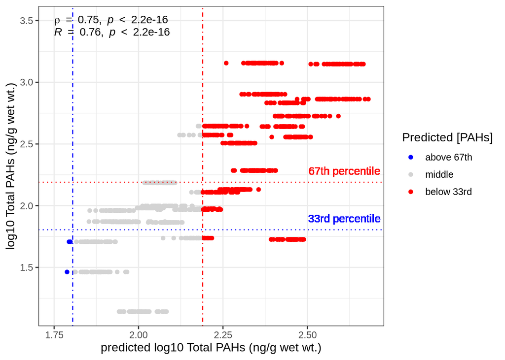

#### Predicted vs actural yy plot by site with CI

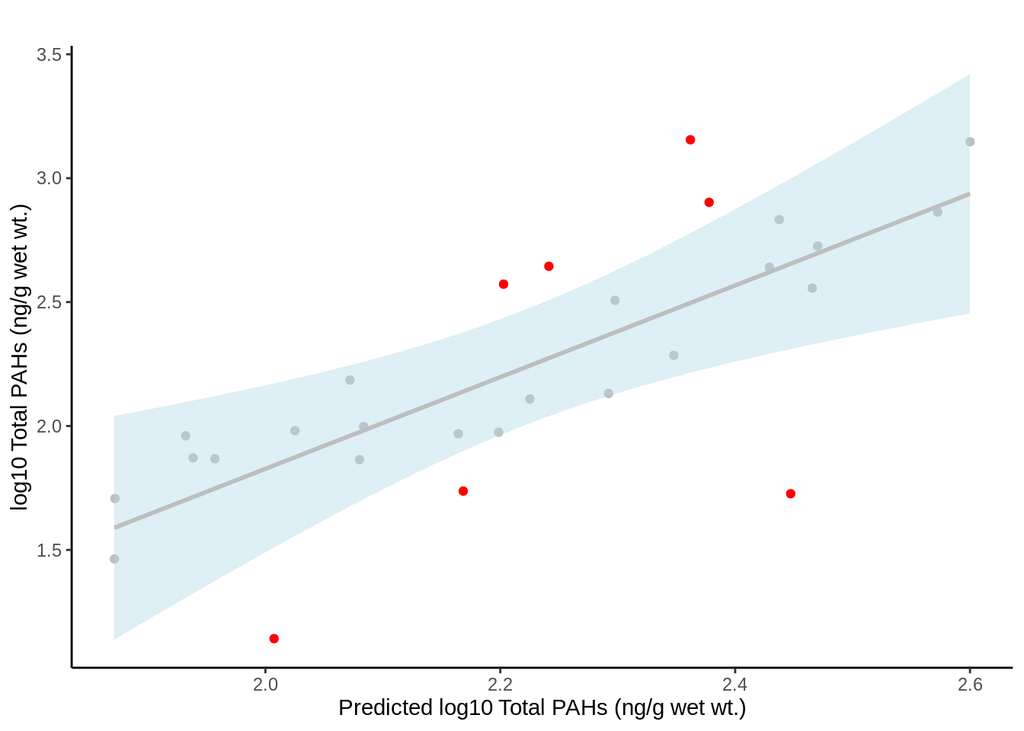

#### model performance

PAHs lasso regression model performance metrics

|  | Pooled PAHs concentrations by site |
| --- | --- |
| error.top | 0.078 |
| error.bottom | 0.000 |
| error.both | 0.078 |
| accuracy.top | 0.743 |
| accuracy.bottom | 1.000 |
| accuracy.both | 0.744 |
| top_ratio | 0.429 |
| bottom_ratio | 0.179 |
| MSE | 0.136 |

#### Predictor genes selected in the model

PAHs top predictor genes and coefficient

[output not shown]

#### PAHs lasso selected genes heatmap

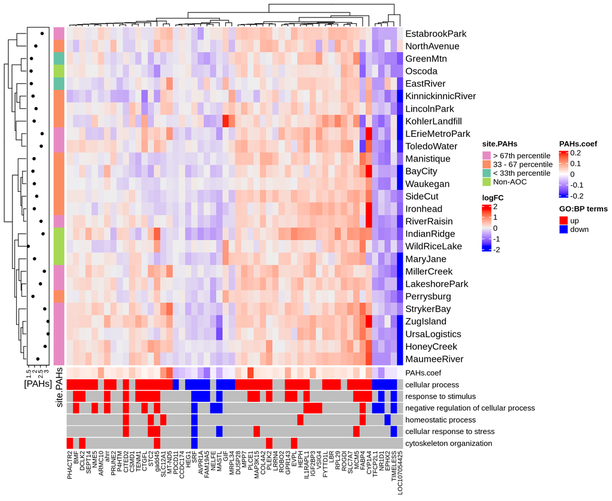

#### PAH correlation between logFC, logCPM, and model coef

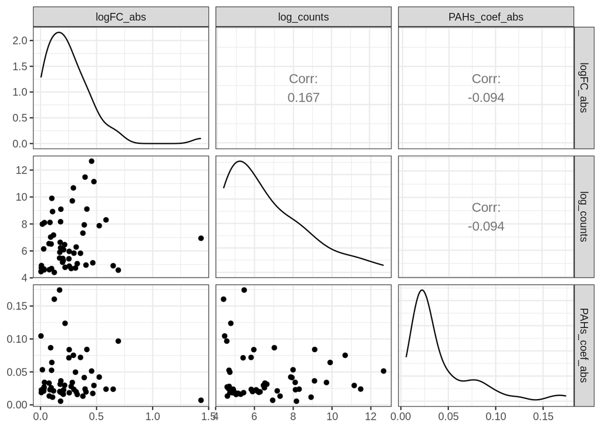

#### PAHs top gene predictors function heatmap

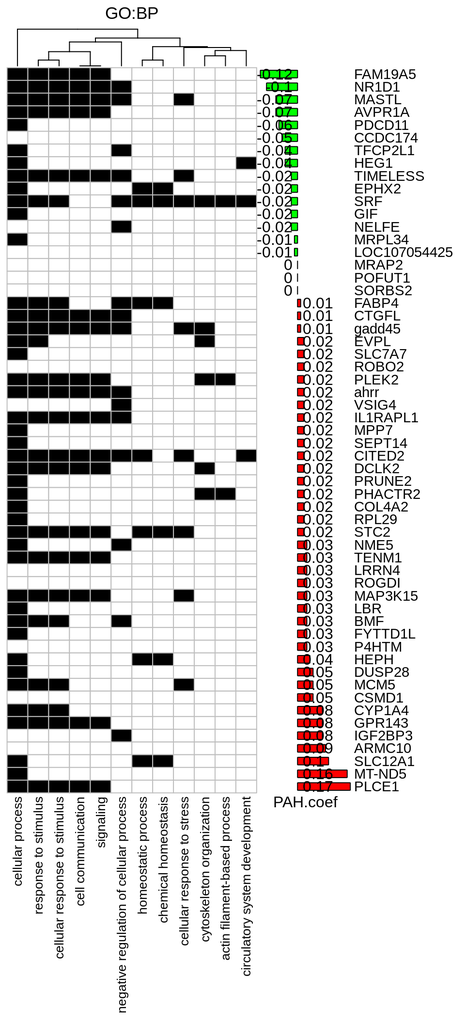